# ANOVA的效果量、檢定力與樣本數

Week 12 · Part 1 · 2026-11-26

## 守備位置不同，上壘率差多少？

- 外野手、內野手和捕手的平均上壘率差多少？
- 如果要重做研究，每一組要找多少人，才有足夠機會看出差異？

## 三個守備位置的平均上壘率都一樣嗎？

- 用單因子變異數分析（one-way ANOVA）比較外野手、內野手和捕手的平均上壘率。

| 變異來源 | 自由度（df） | 平方和（SS） | 均方（MS） | $F$ 值 | $p$ 值 |
| --- | --- | --- | --- | --- | --- |
| 守備位置（組間） | 2 | 0.0161 | 0.0080 | 5.08 | 0.0066 |
| 殘差（組內） | 426 | 0.6740 | 0.0016 | — | — |

- 整體檢定支持至少兩組的平均上壘率不同。
- 三組平均的差距，跟同一個守備位置裡球員彼此的差異相比，有多大？

IMS 2e Table 22.5（p. 387）。

## 三組平均上壘率分得有多開？

- 哪兩組的平均最接近？
- 再用各組的標準差比較同一個守備位置的球員有多分散。

| 守備位置 | 人數 | 平均上壘率（OBP） | 標準差 |
| --- | --- | --- | --- |
| 外野手 | 160 | .320 | .043 |
| 內野手 | 205 | .318 | .038 |
| 捕手 | 64 | .302 | .038 |

- 三組平均落在 30.2% 到 32.0%，各組內的標準差約 3.8 到 4.3 個百分點。
- 同一個位置的球員，上壘率也有不小的差異。
- 如果組平均的差距固定，組內越分散，組間差異占總變異的比例會怎麼變？

IMS 2e Table 22.3（p. 381）。

## 量表分數：兩組平均都差 4 分，組間變異占比一樣嗎？

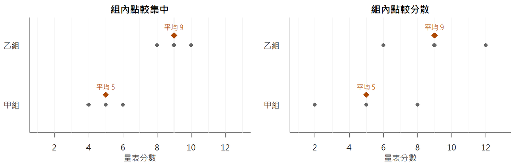

每個灰點是一位受試者，橘色菱形是組平均。兩圖的橫軸尺度相同。

- 兩圖都是甲組平均 5、乙組平均 9。
- 先猜哪張圖的組間平方和占總平方和的比例較大。

本課自編量表示例，各組人數相同。兩圖刻意固定組平均，改變組內分散程度。

## 同樣是組間 24，為什麼比例從 .86 降到 .40？

- 前頁的左右兩圖改成上下排列：上圖較集中，下圖較分散。
- 每組 3 人，兩組平均分別為 5 和 9，總平均為 7。
- 組間平方和都是 $3(5-7)^2+3(9-7)^2=24$。

| 圖 | 組內平方和 | 組間占比 |
| --- | --- | --- |
| 上圖（較集中） | 4 | 約 .86 |
| 下圖（較分散） | 36 | .40 |

- **上圖** 組內平方和 $2(1^2+0^2+1^2)=4$，組間占比 $24/(24+4)\approx .86$。
- **下圖** 組內平方和 $2(3^2+0^2+3^2)=36$，組間占比 $24/(24+36)=.40$。
- 組間平方和相同時，組內分數越分散，組間平方和占總平方和的比例越小。

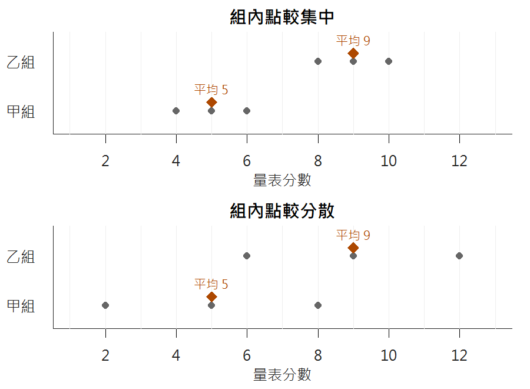

橘色菱形標出組平均。沿橫軸看灰點離組平均幾分。

本課自編例題，取前頁兩組各 3 筆量表分數計算。

## 上壘率的總變異中，有多少來自守備位置的組間差異？

- 棒球資料的組間平方和是 .0161，組內平方和是 .6740。
- 用組間平方和除以總平方和，就得到一種效果量（effect size），叫做 eta 平方（eta squared，$\eta^2$）。

$$\eta^2=\frac{SS_{\text{組間}}}{SS_{\text{總}}}
=\frac{.0161}{.0161+.6740}\approx .0233.$$

- 這份樣本的上壘率總變異中，約 **2.3%** 是不同守備位置之間的差異，約 97.7% 是同一位置的球員彼此之間的差異。
- 要問換守備位置會不會改變球員的上壘率，還需要能支持因果推論的研究設計。

IMS 2e Table 22.5（p. 387）。效果量依課本表中的四捨五入平方和另算。

## 還沒收資料，先怎麼估需要幾人？

- 剛才的 2.3% 是從已收集的棒球資料算出來的。
- 現在假想要重新招募三組球員。
- 先決定想偵測到多大的平均差，再估計組內波動有多大。
- 有了這些假設，才能估每組需要多少人。

## 如果重做上壘率研究，每組要收多少人？

- 用三組球員在原研究中的樣本平均，作為新研究的母體平均假設。
- 假定這些平均值成立，再估需要多少人，才有足夠的機會偵測到這樣的差距。

| 規劃條件 | 設定 |
| --- | --- |
| 三組母體平均 | .320、.318、.302 |
| 共同組內標準差 | .040 |
| 顯著水準與目標檢定力（power） | $\alpha=.05$、$1-\beta=.80$ |
| 設計與檢定 | 三個獨立組，每組同樣多人。做整體單因子 $F$ 檢定。 |

- 照同一個設計重做很多次研究，若母體的平均和標準差符合表中的規劃假設，檢定力 .80 表示約八成的研究會拒絕「三組平均都相同」。

以 IMS 2e Table 22.3（p. 381）為規劃起點。本課設定共同組內標準差 .040，與課本合併組內標準差約 .0398 接近（Table 22.5）。

## 三個預期平均分得多開？

- 要估人數，先把三組平均的分散程度和組內波動相比。

$$f=\frac{\sqrt{\frac{1}{k}\sum_{j=1}^{k}(\mu_j-\bar\mu)^2}}{\sigma}
=\frac{.00806}{.040}\approx .201.$$

- `Cohen's` $f$ 的分子是三個預期平均離中心 $\bar\mu$ 的均方根距離（$k=3$，等權重），約 .00806。
- 分母 .040 是共同組內標準差。
- $f\approx.201$ 表示組平均的分散程度約為組內波動的五分之一。
- 有了規劃的效果量，先試每組 81 人，看看檢定力是怎麼算出來的。為什麼是 81 人，等一下會從檢定力曲線上找出來。

依 IMS 2e Table 22.3（p. 381）設定課堂例題。參考 R `power.anova.test` 說明。

## 如果三組平均都相同，$F$ 多大才算少見？

- 三組母體平均都相同時，每組 81 人的 $F$ 服從中心 $F$ 分布（central $F$ distribution），自由度為 2 和 240。

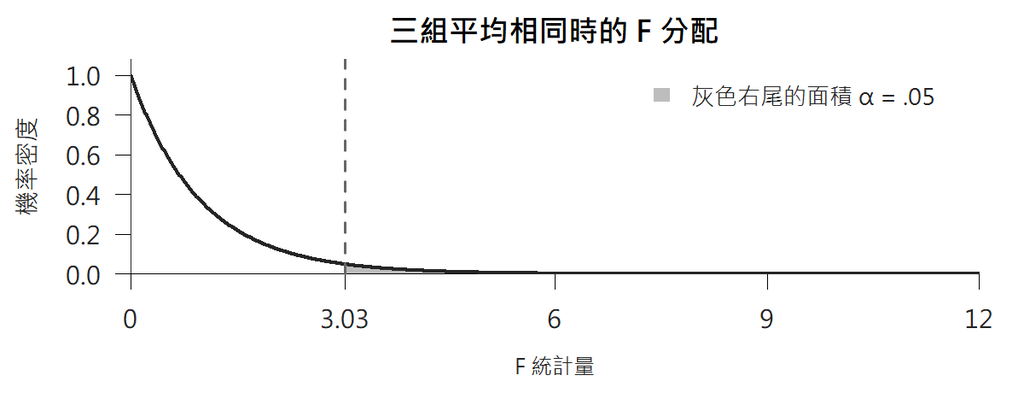

虛線右側的面積是 .05。沿著橫軸找出拒絕門檻。

- 門檻約是 **3.03**。三組平均真的相同時，重做 100 次，平均約有 5 次會誤判有差異。

本課自製圖。每組 81 人，整體單因子 $F$ 檢定的臨界值由 R 計算。

## 三組平均真的有差，這條界線會抓到幾成？

- 每組仍是 81 人。若母體平均 .320、.318、.302 和共同組內 SD .040 成立，$F$ 服從非中心 $F$ 分布（noncentral $F$ distribution）。

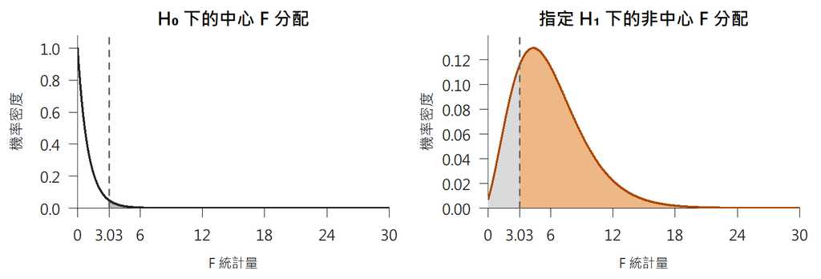

兩圖的橫軸同尺度，縱軸刻度不同。沿用同一個門檻，右圖哪一塊是檢定力？

- 右圖橘色是檢定力 $1-\beta$，約 **80.4%**。灰色是未偵測到差異的機率 $\beta$，約 19.6%。

依 IMS 2e Table 22.3（p. 381）自訂規劃情境。尾端面積以完整分布計算。

## 兩條 $F$ 曲線的自由度一樣嗎？

- 兩條曲線都是三組、每組 81 人，總共 243 人。
- 自由度和非中心參數（noncentrality parameter）各有什麼差別？

|  | $H_0$ 下的中心 $F$ | 指定 $H_1$ 下的非中心 $F$ |
| --- | --- | --- |
| 分子自由度 $k-1$ | $3-1=2$ | $3-1=2$ |
| 分母自由度 $N-k$ | $243-3=240$ | $243-3=240$ |
| 非中心參數 $\lambda$ | 0 | 9.855 |

- 平常寫 $F_{2,240}$，指的是 $\lambda=0$ 的中心 $F$。這個例子的非中心 $F$ 寫成 $F_{2,240}(9.855)$。
- $\lambda$ 量的是：規劃的組間差距換成抽樣波動的單位後有多大。$H_0$ 下沒有差距，所以是 0。
- $\lambda$ 越大，$F$ 越容易超過門檻。9.855 怎麼從平均和人數算出來，後面比較 $t$ 和 $F$ 時再細看。
- 每換一個樣本數，分母自由度和 $\lambda$ 都會跟著變，檢定力就要重算。

沿用 IMS 2e Table 22.3（p. 381）的棒球規劃情境。三組等人數時，$\lambda=Nf^2$。

## 在曲線上找 .80，要讀到幾人？

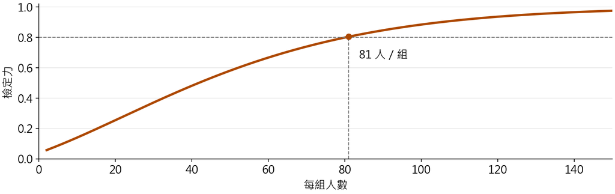

從縱軸的 .80 往右找到橘線，再往下讀每組人數。

- 達到 .80 的交點約在每組 80.20 人，往上取到整數，也就是 **每組 81 人，合計 243 人**。
- 每組 81 人時，檢定力約 .804。
- 如果組內波動比我們估的大，這個人數還夠嗎？

依 IMS 2e Table 22.3（p. 381）的規劃情境自製。結果以 R `power.anova.test` 驗算。

## 練習｜組內波動更大，81 人還夠嗎？

- 規劃新研究時，三個守備位置的預期平均維持 .320、.318、.302。
- 如果原先的組內 SD 估得太樂觀，實際上是 .050 而不是 .040，每組 81 人還夠嗎？
- 先想想：組內 SD 變大，$f$ 的分子還是分母會變？
- 組內 SD 在分母，分母變大，$f$ 從 .201 降到 .161。每組仍是 81 人時，$\lambda$ 從 9.855 降到 6.307。
- 檢定力從約 .80 降到 .60。
- 要回到 .80，就要增加到 **每組 125 人**。

依 IMS 2e Table 22.3（p. 381）設定預期平均。共同 SD .050 為本課規劃情境，檢定力以 R 試算。

## 練習｜如果三組平均沒差那麼遠？

- 把共同 SD 放回 .040。
- 這次把三個預期平均都往中心移，離中心的距離只留原來的 75%。
- 每組還是 81 人，$\alpha=.05$。
- 共同組內 SD 會改變 $f$ 的分母。
- **縮小組平均的差距，會改變分子還是分母？**
- 這次是分子變小。
- 三個平均之間的距離只剩原來的 75%，所以 $f$ 從 .201 降到約 .151。
- 每組仍是 81 人，檢定力從 **.804 降到 .543**。
- 若要回到 .80，就要增加到 **每組 142 人**。

以 IMS 2e Table 22.3（p. 381）的三組平均設定基準。差距縮小是本課的規劃情境。

## 三種情況達到 .80，各需要多少人？

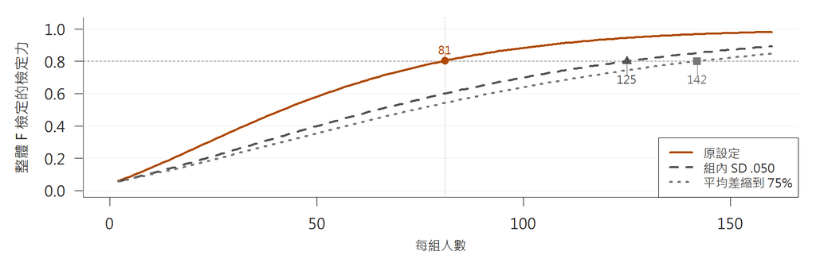

水平虛線是 .80。三個標記顯示各情境達標的最少人數，垂直點線標在每組 81 人。

- 每組人數相同時，組內波動變大或組平均靠得更近，檢定力都會下降。
- 原設定每組 81 人就達標。組內波動變大時要 125 人，組間差距縮小時要 142 人。

依 IMS 2e Table 22.3（p. 381）設定。三組等人數，整體單因子 F，α＝.05。

## 練習｜預算只夠每組 81 人，怎麼寫計畫？

- 預算只夠每組 81 人。
- 用右圖和表格找出檢定力能達到 .80 的情境。
- 用一句話說明，在什麼假設下每組 81 人就夠。

| 規劃假設 | 達 .80 需要幾人／組？ |
| --- | --- |
| 原先的平均差，SD .040 | 81 |
| 原先的平均差，SD .050 | 125 |
| 平均差只剩原來的 75%，SD .040 | 142 |

- 「原先的平均差和 SD .040 都成立時，每組 81 人可達 .80。」
- 只改 SD，增到 .050 時，檢定力約 .60。
- 只改組間差距，縮小 25% 時，檢定力約 .54。

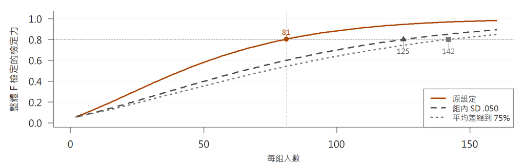

沿著每組 81 人的垂直點線，比較三條曲線離 .80 有多遠。

依 IMS 2e Table 22.3（p. 381）設定情境。數值為等人數獨立組的規劃試算。

## 比兩組和比三組，效果量怎麼算？

- 剛才用整體 $F$ 檢定比較三個守備位置。
- 如果新研究只想知道外野手和捕手的平均上壘率是否不同，就在收資料前指定這一對，用雙尾 $t$ 檢定來規劃。
- 兩種設計都假設共同組內 SD 為 .040。

|  | 雙尾兩獨立樣本 $t$ 檢定 | 單因子 ANOVA 的整體 $F$ 檢定 |
| --- | --- | --- |
| 研究問題 | 外野手和捕手平均上壘率不同嗎？ | 三個守備位置平均上壘率都一樣嗎？ |
| 預期平均 | .320、.302 | .320、.318、.302 |
| 分子怎麼算？ | 兩組預期平均相差 .018 | 三組預期平均離中心的均方根距離約 .00806 |
| 除以共同組內 SD | `Cohen's` $d=.45$ | `Cohen's` $f\approx .201$ |

依 IMS 2e Table 22.3（p. 381）的平均值設定本課規劃例。

## 比兩組或比三組，各要收多少人？

- 有了預期平均和組內 SD，就能估每組人數。
- 每種設計內都採等人數分組，顯著水準取 .05，目標檢定力取 .80。

|  | 雙尾兩獨立樣本 $t$ 檢定 | 單因子 ANOVA 的整體 $F$ 檢定 |
| --- | --- | --- |
| R 函數 | `power.t.test()` | `power.anova.test()` |
| 要輸入什麼？ | 預期平均差 .018、組內 SD .040 | 組數 3、三個預期平均的 `var()`、組內變異數 $.040^2$ |
| 每組至少幾人？ | 約 78.49，進位到 **79 人** | 約 80.20，進位到 **81 人** |
| 總共招募幾人？ | **158 人**（$2\times79$） | **243 人**（$3\times81$） |

- 如果每組少收一人，檢定力還能到 .80 嗎？
- 158 人用來回答外野手和捕手的比較，243 人用來回答三個守備位置的整體比較。這兩個人數都依照表中的規劃假設算出來。

依 IMS 2e Table 22.3（p. 381）的平均值設定本課規劃例。人數用 R 試算。

## 兩種檢定的非中心參數各在量什麼？

- 兩種檢定都要先設定想偵測的差距。
- 令 $n$ 為每組人數，把差距換成標準誤的單位，就能看出它相對於抽樣波動有多大。

**雙尾** $t$ 檢定

- 把兩組預期平均差除以這個差的標準誤。

$$\lambda_t(n)=\frac{\mu_1-\mu_2}{\sigma\sqrt{2/n}}
=d\sqrt{n/2}$$

- 每組 79 人時，外野手和捕手的預期差 .018，約是平均差標準誤的 **2.83 倍**。
- 預期差距的方向決定 $\lambda_t$ 的正負。

**整體** $F$ 檢定

- 用單組平均的標準誤 $\sigma/\sqrt n$ 作單位，量每個預期平均離總平均多遠，再把三個距離平方加總。

$$\lambda_F(n)=\sum_{j=1}^{3}
\left(\frac{\mu_j-\bar\mu}{\sigma/\sqrt n}\right)^2
=3nf^2$$

- 每組 81 人時，平方加總得到 **9.855**。
- 高於和低於總平均的差距都算進去。

沿用 IMS 2e Table 22.3（p. 381）的棒球規劃例。各組等人數，共同組內 SD 為 .040。

## 怎麼找到達標的最少人數？

- 每試一個 $n$，先用 $H_0$ 下的分布找臨界值，再用非中心參數 $\lambda(n)$ 求拒絕域的機率。

**雙尾** $t$ 檢定

- 中心 $t$ 的兩尾各留 .025。

$$P_{\lambda_t(n)}\!\left(|T|>t_{.975,\,2n-2}\right)$$

- 每組 78 人時為 .7975，**79 人**時為 .8026。

**整體** $F$ 檢定

- 中心 $F$ 的右尾留 .05。

$$P_{\lambda_F(n)}\!\left(F>F_{.95;\,2,3(n-1)}\right)$$

- 每組 80 人時為 .7990，**81 人**時為 .8042。
- 找第一個使檢定力達到 .80 的整數 $n$。

$$n_{\min}=\min\{n\ge 2:\mathrm{Power}(n)\ge .80\}$$

依 IMS 2e Table 22.3（p. 381）設定規劃情境。臨界值與尾端機率以 R 計算。

## 每組要收幾人，是由哪些數字決定的？

- 效果量描述已經收完的資料。棒球例的 $\eta^2\approx .023$：守備位置的組間差異約占上壘率總變異的 2.3%。
- 規劃新研究時，先寫下想偵測的平均差、組內 SD、$\alpha$ 和目標檢定力。這些假設決定 `Cohen's` $f$ 和 $\lambda$，再決定每組人數。
- 組內波動變大，或組平均靠得更近，同樣的人數檢定力就下降，要收更多人：81 人變成 125 人或 142 人。
- 要比哪些組也要先說清楚。只比外野手和捕手，每組 79 人。三組整體比較，每組 81 人。
- 休息後換成同一批人量好幾次。那時除了平均和波動，還要考慮同一人的讀值怎麼一起變。

整合 IMS 2e Tables 22.3、22.5（pp. 381、387）的棒球例與本課規劃情境。

## Slido｜Part 1 效果量、檢定力與樣本數

[figure not shown]

Week 12 Part 1 Slido 作答 QR code

[開啟 Slido 作答頁](https://qr.sli.do/5HDVvewXzbksXLBFjcjX8S) · 活動代碼 **2773247**